# 3-c-1 QA

Emma Wood

16/12/2021

**Run date and time: 2022-05-05 15:58:47**

## Introduction

3-c-1 is a relatively straightforward indicator but it is an easy automation as the data are from Nomis, and there is a calculation that is easier to do without error in R.

This file runs some basic checks and gives information about the update.

## Configurations

The config file contains only two values:

- nomis_employment_link: data from the ‘annual population survey - regional - employment by occupation’ table on Nomis.
- nomis_population_link: data from the ‘population estimates - local authority based by 5 year age band’ table on Nomis.

The details of how these links are generated is given in the README file in the 3-c-1 folder. Links do not need to be updated unless the selections (e.g. of occupations) change.

## Basic checks

We should only use data for the calendar year (Jan-Dec). The months contained in the data for this run are: Jan -Dec . If the given months are incorrect please check the nomis selections are correct, and regenerate the link (see the 3-c-1 README file).

```r
if (not_all_data_available == TRUE) {
  print(paste("NOTE: Data for", dataset_behind, "data are only available up to",
              max_years$max_year[max_years$dataset == dataset_behind],
              ", though data for", max_years$dataset[max_years$dataset != dataset_behind],
              "are available up to", max_years$max_year[max_years$dataset != dataset_behind]))
}
```

```
## [1] "NOTE: Data for population data are only available up to 2020 , though data for employment are available up to 2021"
```

## Plots

[output not shown]

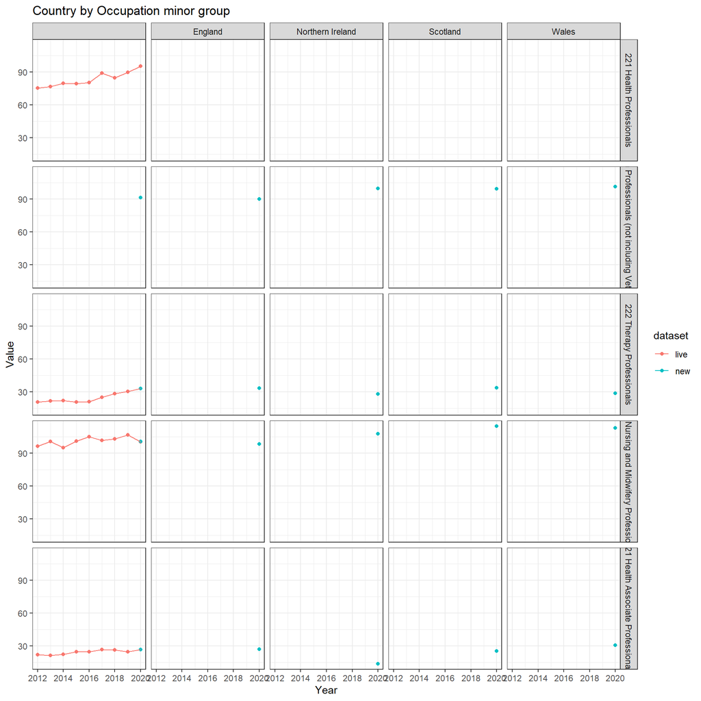

[output not shown]

[output cut: 97 more lines]

[output not shown]

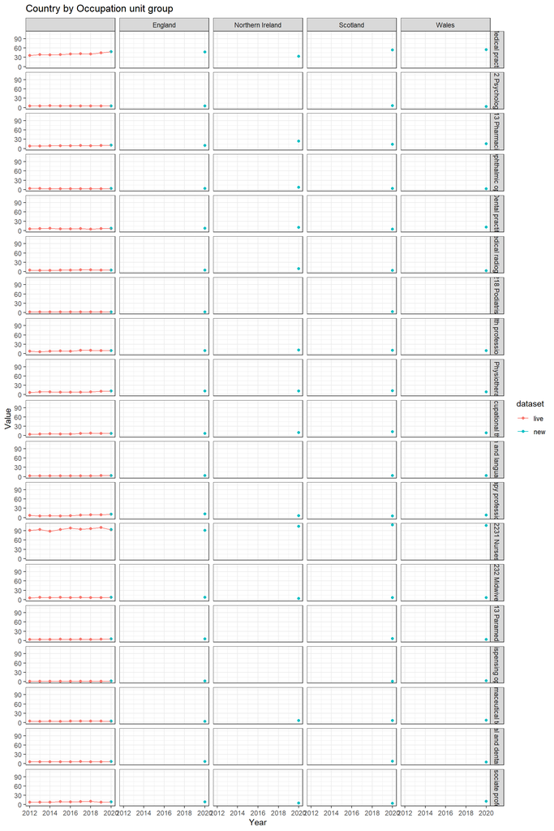

[output not shown]

[output cut: 25 more lines]

[output not shown]

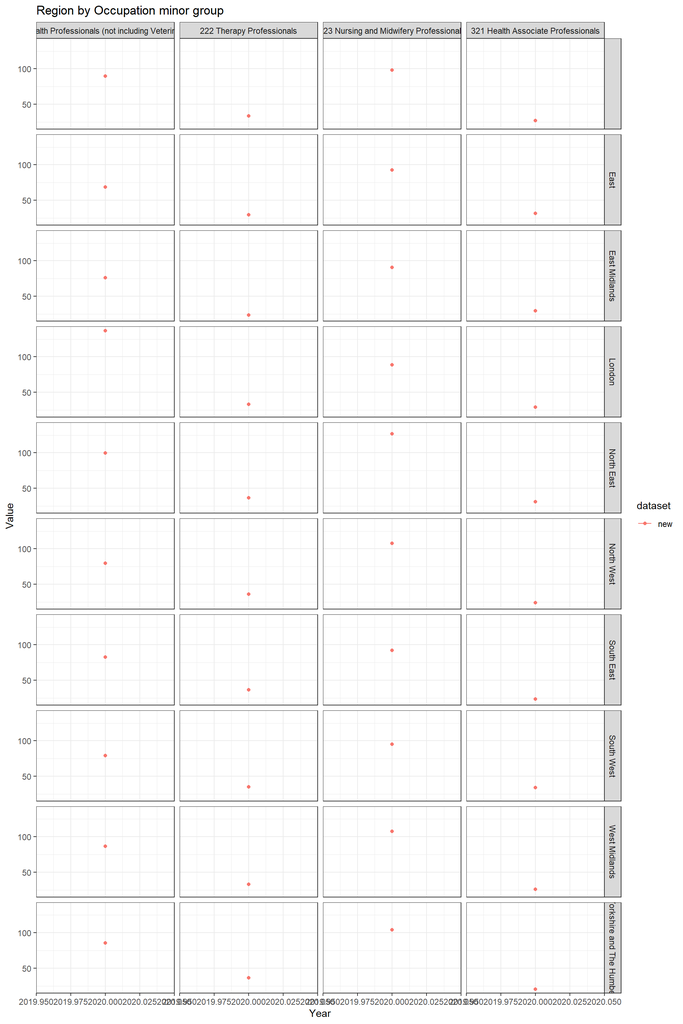

[output not shown]

[output cut: 325 more lines]

[output not shown]

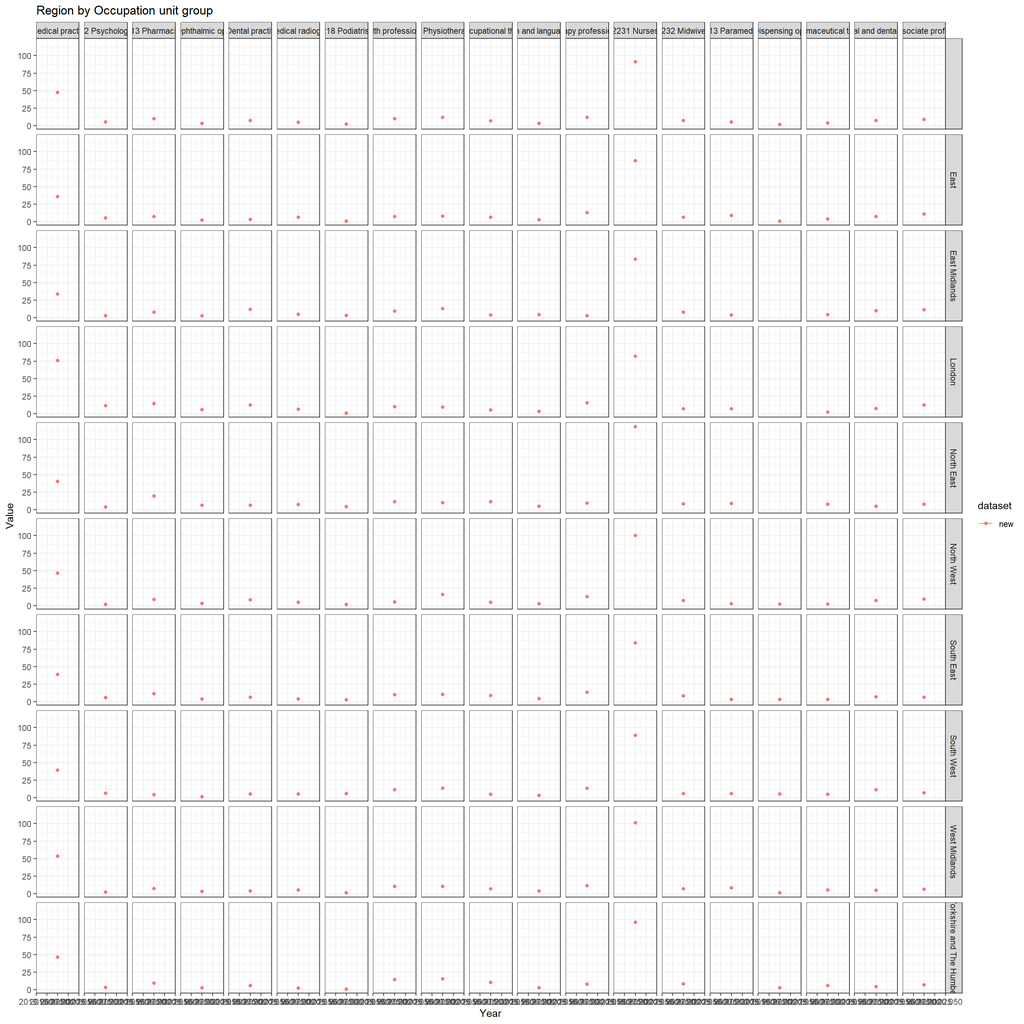